# Project 3

Júlíus Pétur Guðjohnsen

Sigurður Jónsson

29.10.2016

# 1 Brain Storming Excersise

## 1.1 Stock price index

After some reserch on stock prices we belive the gross domestic priduct (*GDP*) would be one causal variable for the stock price index (*SPI*). Althog we currently have restriction og currency exhance here in iceland we belive that in an unrestricted market in a small country like iceland tha exchange rate (*ER*) would have a big impact on the SPI, specialy for companies in tha export buisness. Another causal variable would be the inflation (*I*) which effects the room for expansion of companies. The last but probably the most importan one would be the companies overal performance (*COP*) this varibal is estimatat according to standart procedures regarid the financial ratios of tha company in question for example *dept coverage ratio* etc. so the strucual equation should look like $\eqref{SPI}$.

\begin{equation} SPI = \alpha + \beta_1 \cdot GDP + \beta_2 \cdot I + \beta_3 \cdot ER + \beta_4 \cdot COP + \epsilon \label{SPI} \end{equation}

We belive that $\beta_1$,$\beta_4$, are positive but $\beta_2$,$\beta_2$, are negative as inflation and exchange rate would have negative effects on the SPI.

## 1.2 Scandinavian electricity market

After reading throug some of the information on http://www.nordpoolspot.com/How-does-it-work/ we concluded tha there are the price seems to be tha classic case of supply (S) and demand (D). the weather (W) plays a big roll in the price but this however most likley is correlated with the demand so it might provide tha same information as the demand variable.

\begin{equation} SEP = \alpha + \beta_1 \cdot S + \beta_2 \cdot D + \beta_3 \cdot W + \epsilon \label{SEP} \end{equation}

## 1.3 Inflation

It seems hard to find concreta data on http://www.hagstofan.com/ regardin how the inflation is evaluated bu it seems that inflation based on Consumer Price Index (CPI), wage index(WI) Cost Of Living (COL) and Money Supply (MS). as increas in all the indexes would result in higer inflation all the $\beta$ constans should be positive.

\begin{equation} I = \alpha + \beta_1 \cdot CPI + \beta_2 \cdot WI + \beta_3 \cdot COL + \beta_4 \cdot ML + \epsilon \label{I} \end{equation}

# 2 Housing Econimocs

## 2.1 Task 1

## 2.2 Task 2

## 2.3 Task 3

## 2.4 Task 4

# 3 Sales modeling

## 3.1 Task 1

For this task we are to construct a salesmodel from the provided dataset. The datesets consists of around 20 variables wich can be used to construct a model for the sales. After some very basis investigation of what the datamodel consists of we come to the conclution of using 4 varibles in tha salesmodel. The first variable (*SE*) is the sesonal variable. tha seasonal varable should account for seasonality in tha data in respect to both the week of year and week of month. We belive tha customers should be more willing to spend money in the first week of the monthe due to a more positive ballance on tha bank account of being payed frome there emplyeer. In respect to the week of year seasonality we should se some classic patterns of consumers for exaple less willingness to purchase after the christmas season and therefor the sign of this variable should be positive. The second varible is the unemployment rate called (*E*) as it should reflect the current economic status of the consumers. It is known that in with higher rates of unemployment the tha purchasing power goes down so this varaible should give insight to the purchasing power and therefor the sign of the economic variable should be negetive(with respect to unemplyment rate). The third varible is weather varible (*W*), we belive that tha wether will have a effect on the sales, we do have some weather parameters in tha data and will have to decide on wich to use with some futher analysis so the sign of the weather variable is hard to estimate without further analysis. The last varable (*M*) is the marketing varible this one should be positive as there should be positive correlation between brandi the store and spending in tha store. Below we can see the salesmodel in equation $\eqref{eq1}$.

\begin{equation} SM = \alpha + \beta_1 \cdot SE + \beta_2 \cdot E + \beta_3 \cdot W + \beta_4 \cdot M + \epsilon \label{eq1} \end{equation}

## 3.2 Task 2

The purpos of this task is to get familiar whith tha dataset we are working with. The obvius first step is simply to plot the sales of the buildingsupply store which we can see in fig.3.1. below we go into further analysis step by step.Hopfully we vwill ba able to end up with a model that follows tha structual eqaution of $\eqref{eq1}$. by combining and droping irrelevent data.

```r
#rm(list=ls())
suppressPackageStartupMessages(require(ggplot2))
suppressPackageStartupMessages(require(ggfortify))
suppressPackageStartupMessages(require(reshape2))
suppressPackageStartupMessages(require(forecast))
source("Multiplot.R")

setwd("C:/Users/Julius/Desktop/Skóli Haust 2016/tima/Assignment3")
BuildingSupplyStore <- read.csv("BSS.csv",stringsAsFactors = FALSE,header=TRUE, sep=";")

BuildingSupplyStore$Week.of.Year <- substr(BuildingSupplyStore[,1], 6, 7)
BuildingSupplyStore$Year <- substr(BuildingSupplyStore[,1], 1, 4)
BuildingSupplyStore$Rtime <- as.numeric(substr(BuildingSupplyStore[,1], 1, 4))+
as.numeric(substr(BuildingSupplyStore[,1], 6, 7) )/52 - 1/52

BuildingSupplyStore$Kalendar <- as.factor(BuildingSupplyStore$Kalendar)
BuildingSupplyStore <- within(BuildingSupplyStore, Kalendar <- relevel(Kalendar, ref = "Normal"))

#sapply(BuildingSupplyStore, class)
summary(BuildingSupplyStore)
```

```
##      Date               Sales              Season             Kalendar
##  Length:181         Min.   : 1209152   Min.   : 6049692   Normal  :144
##  Class :character   1st Qu.: 9782378   1st Qu.: 8467615   1.easter:  4
##  Mode  :character   Median :12195746   Median : 9898062   1.pinse :  4
##                     Mean   :12236093   Mean   :10181578   2.easter:  4
##                     3rd Qu.:14745707   3rd Qu.:11914229   2.pinse :  4
##                     Max.   :23853027   Max.   :15186016   Newyear :  4
##                                                           (Other) : 17
##  Week.of.Month   Competitor.spending    Salgdage     Unemployment.rate
##  Min.   :1.000   Min.   :12.19       Min.   :19.00   Min.   :1.617
##  1st Qu.:2.000   1st Qu.:13.71       1st Qu.:60.00   1st Qu.:1.753
##  Median :3.000   Median :14.04       Median :70.00   Median :2.014
##  Mean   :2.702   Mean   :13.95       Mean   :67.96   Mean   :2.148
##  3rd Qu.:4.000   3rd Qu.:14.28       3rd Qu.:72.00   3rd Qu.:2.537
##  Max.   :5.000   Max.   :14.93       Max.   :84.00   Max.   :3.051
##
##     Tracking     Tracking.smoothed Respons.Media        Sol.Oslo
##  Min.   :24.60   Min.   :30.34     Min.   : 904980   Min.   :  0.00
##  1st Qu.:33.20   1st Qu.:35.00     1st Qu.:3342127   1st Qu.: 15.40
##  Median :38.40   Median :39.12     Median :4418746   Median : 29.50
##  Mean   :37.47   Mean   :38.31     Mean   :4439955   Mean   : 33.90
##  3rd Qu.:41.20   3rd Qu.:41.60     3rd Qu.:5520284   3rd Qu.: 50.55
##  Max.   :52.40   Max.   :44.69     Max.   :7238330   Max.   :107.00
##
##  Oslo...Mean.temperature Oslo...Total.precipitation
##  Min.   :-8.4714         Min.   : 0.00
##  1st Qu.: 0.8571         1st Qu.: 3.10
##  Median : 6.4000         Median :12.80
##  Mean   : 6.7730         Mean   :17.42
##  3rd Qu.:13.1429         3rd Qu.:24.90
##  Max.   :21.5714         Max.   :87.10
##
##  Bergen...Mean.temperature Bergen...Total.precipitation     Print
##  Min.   :-3.914            Min.   :  0.00               Min.   : 163648
##  1st Qu.: 4.014            1st Qu.: 13.60               1st Qu.: 619607
##  Median : 8.071            Median : 41.50               Median : 990552
##  Mean   : 8.335            Mean   : 49.96               Mean   :1414616
##  3rd Qu.:11.929            3rd Qu.: 78.00               3rd Qu.:1736965
##  Max.   :20.786            Max.   :210.20               Max.   :5372925
##
##     InStore        DirectMarketing      RADIO          TV.Taktisk
##  Min.   :      0   Min.   :     0   Min.   :     0   Min.   :      0
##  1st Qu.:   2510   1st Qu.:122255   1st Qu.:     0   1st Qu.:      0
##  Median :   4144   Median :242613   Median :     0   Median :      0
##  Mean   :  26982   Mean   :217089   Mean   : 19540   Mean   : 446040
##  3rd Qu.:   4317   3rd Qu.:324800   3rd Qu.: 16038   3rd Qu.: 845804
##  Max.   :1508372   Max.   :489475   Max.   :326907   Max.   :2108291
##
##     TV.Image       Week.of.Year           Year               Rtime
##  Min.   :      0   Length:181         Length:181         Min.   :2006
##  1st Qu.:      0   Class :character   Class :character   1st Qu.:2007
##  Median :      0   Mode  :character   Mode  :character   Median :2008
##  Mean   : 365365                                         Mean   :2008
##  3rd Qu.: 742874                                         3rd Qu.:2009
##  Max.   :2081367                                         Max.   :2009
##
```

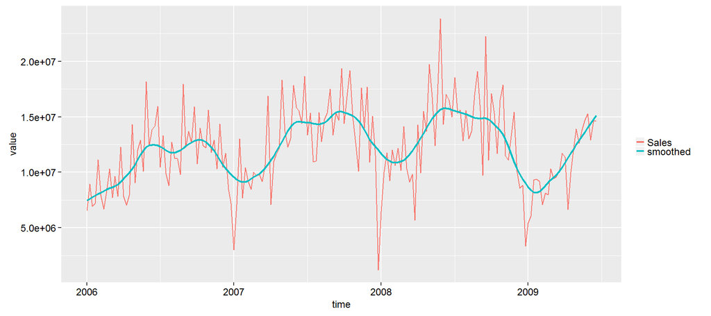

Figure 3.1: Sales from 2006 to mid 2009

```r
attach(BuildingSupplyStore)

df <-BuildingSupplyStore[,c(25,2)]
#df[,1] <- as.Date(paste(df$Date,1,sep = "-"),format="%Y-%W-%w")
df[,2] <- as.numeric(df[,2])
smoothSales <- lowess(Sales, f=.1)
df$smoothed <- smoothSales$y
df <- melt(df,id=1)
ggplot(data = df, aes(x=Rtime))+
geom_line(data = df[df$variable!="smoothed",], aes(y=value,colour=variable),size=0.4)+
geom_line(data=df[df$variable=="smoothed",], aes(y=value,colour=variable),size=0.8)+

theme(legend.title = element_blank())+
#theme(legend.title = element_text(colour=rgb(0,0,0), size=9 ))+
theme(legend.position="right")+
theme(legend.text = element_text(colour=rgb(0,0,0), size=9))+
theme(legend.background = element_rect(fill=rgb(1,1,1), size=0.2, linetype=2))+
theme(legend.key.size = unit(0.3, "cm"))+
theme(axis.text.x = element_text(size=9, colour = rgb(0,0,0)))+
theme(axis.text.y = element_text(size=9, colour = rgb(0,0,0)))+
theme(axis.title.x = element_text(size=9))+
theme(axis.title.y = element_text(size=9))+
labs(x = "time")
```

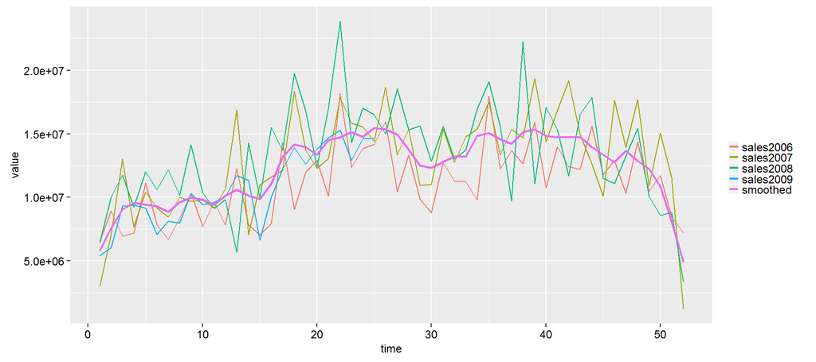

Figure 3.2: The Weekly sales for each year

```r
#plot the years stacked, sails as a function of week
df2 <- data.frame(matrix(ncol = 6, nrow = 52))
x <- c("Week","sales2006", "sales2007", "sales2008","sales2009","smoothed")
colnames(df2) <- x

df2$Week[1:52] = 1:52
df2$sales2006[1:52] = BuildingSupplyStore$Sales[(BuildingSupplyStore$Year == "2006")]
df2$sales2007[1:52] = BuildingSupplyStore$Sales[(BuildingSupplyStore$Year == "2007")]
df2$sales2008[1:52] = BuildingSupplyStore$Sales[(BuildingSupplyStore$Year == "2008")]
df2$sales2009[1:25] = BuildingSupplyStore$Sales[(BuildingSupplyStore$Year == "2009")]

smootheWeek <- lowess(rowMeans(df2[,c(2:5)],na.rm = TRUE)~df2$Week, f=.1)
df2$smoothed <- smootheWeek$y

df2 <- melt(df2,id=1)
df2 <- na.omit(df2)

ggplot(data = df2, aes(x=Week)) +
geom_line(data = df2[df2$variable!="smoothed",], aes(y=value,colour=variable),size=0.4)+
geom_line(data = df2[df2$variable=="smoothed",], aes(y=value,colour=variable),size=0.8)+

theme(legend.title = element_blank())+
#theme(legend.title = element_text(colour=rgb(0,0,0), size=9 ))+
theme(legend.position="right")+
theme(legend.text = element_text(colour=rgb(0,0,0), size=9))+
theme(legend.background = element_rect(fill=rgb(1,1,1), size=0.2, linetype=2))+
theme(legend.key.size = unit(0.3, "cm"))+
theme(axis.text.x = element_text(size=9, colour = rgb(0,0,0)))+
theme(axis.text.y = element_text(size=9, colour = rgb(0,0,0)))+
theme(axis.title.x = element_text(size=9))+
theme(axis.title.y = element_text(size=9))+
labs(x = "time")
```

Now its goot to go some baskic priliminary analysis like ACF and PACF plots of tha data, as we can see in fig.3.3 there is a clear pattern in tha plots so hopfully we will be able to brake down the data and make a good model

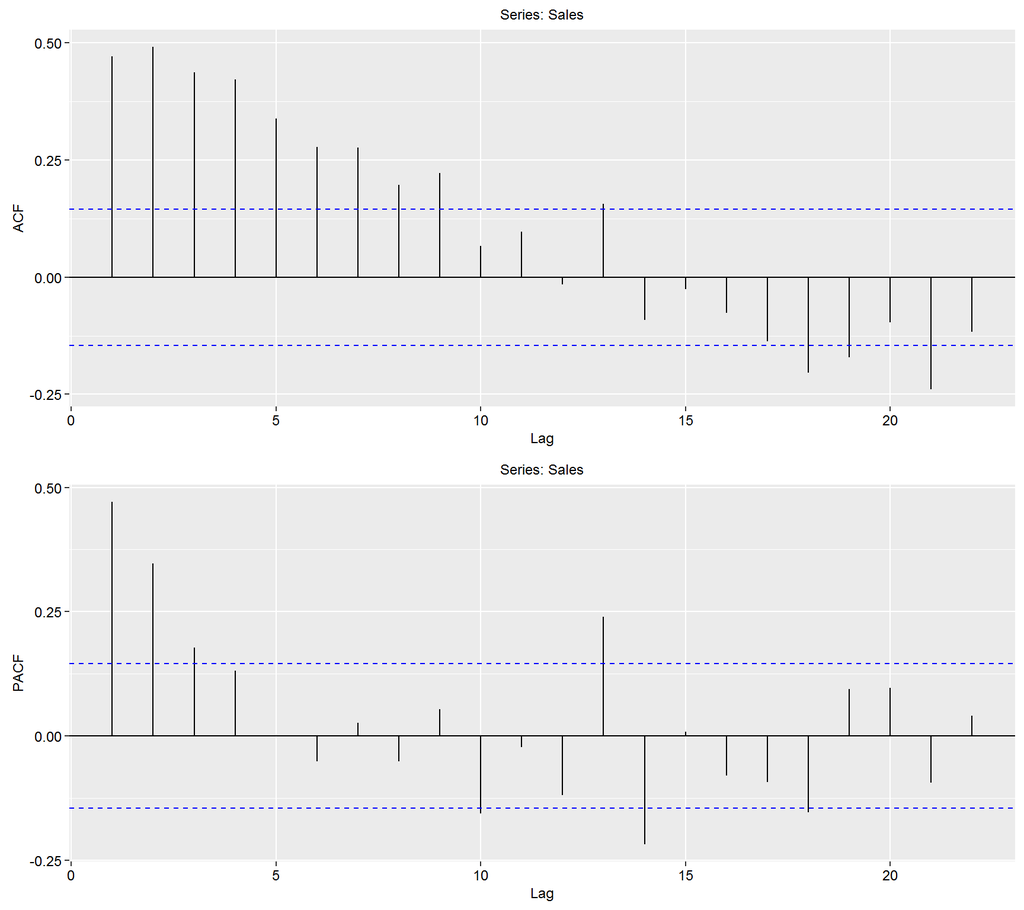

Figure 3.3: AFC plot (top) and the PACF (bottom) of the Sales numbers

The next step was to make a full model usin all the available parameters in tha data, We will hopfully be able to improve ths model with the methods descussed in lecturs. The full model in fig.3.4 will serve as tha benchmark to beat. tha aime is to reduce tha parameters needed to derive a model and therafor reduce the posabillity of varibal inflation and other negative aspects of using all the parameters in a sigle model.

```
##
## Call:
## lm(formula = Sales ~ Rtime + Season + Week.of.Month + Competitor.spending +
##     Salgdage + Unemployment.rate + Tracking.smoothed + Sol.Oslo +
##     Oslo...Mean.temperature + Oslo...Total.precipitation + Bergen...Mean.temperature +
##     Bergen...Total.precipitation + Print + InStore + DirectMarketing +
##     TV.Image + TV.Taktisk, data = BuildingSupplyStore)
##
## Residuals:
##      Min       1Q   Median       3Q      Max
## -5645430 -1235481   -47462  1122488  6890974
##
## Coefficients:
##                                Estimate Std. Error t value Pr(>|t|)
## (Intercept)                   1.340e+09  8.672e+08   1.545 0.124335
## Rtime                        -6.648e+05  4.300e+05  -1.546 0.124031
## Season                        6.539e-01  8.905e-02   7.344 9.41e-12 ***
## Week.of.Month                -7.202e+05  1.279e+05  -5.630 7.70e-08 ***
## Competitor.spending          -2.753e+05  4.332e+05  -0.635 0.526006
## Salgdage                      1.059e+05  2.226e+04   4.756 4.33e-06 ***
## Unemployment.rate            -1.934e+06  5.360e+05  -3.609 0.000409 ***
## Tracking.smoothed             2.426e+04  1.006e+05   0.241 0.809835
## Sol.Oslo                      7.924e+03  1.027e+04   0.772 0.441471
## Oslo...Mean.temperature       1.215e+05  8.707e+04   1.395 0.164830
## Oslo...Total.precipitation    4.038e+02  1.015e+04   0.040 0.968317
## Bergen...Mean.temperature    -2.045e+04  1.128e+05  -0.181 0.856396
## Bergen...Total.precipitation -5.578e+03  4.035e+03  -1.382 0.168770
## Print                         8.729e-01  1.658e-01   5.263 4.41e-07 ***
## InStore                      -5.962e-01  1.126e+00  -0.530 0.597077
## DirectMarketing               1.851e+00  1.287e+00   1.438 0.152440
## TV.Image                      7.481e-01  3.452e-01   2.167 0.031660 *
## TV.Taktisk                   -5.628e-02  4.193e-01  -0.134 0.893395
## ---
## Signif. codes:  0 '***' 0.001 '**' 0.01 '*' 0.05 '.' 0.1 ' ' 1
##
## Residual standard error: 2044000 on 163 degrees of freedom
## Multiple R-squared:  0.7232, Adjusted R-squared:  0.6944
## F-statistic: 25.06 on 17 and 163 DF,  p-value: < 2.2e-16
```

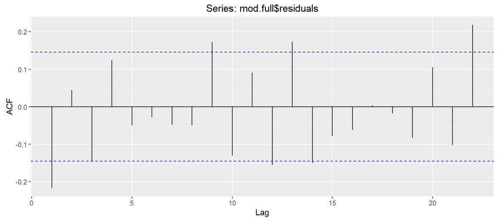

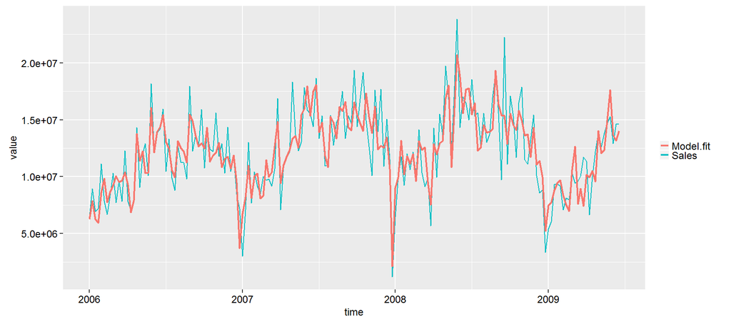

Figure 3.4: ACF of residual for the first basic Linnear regression model (top) and tha fit of the model (bottom)

```r
mod.full <- lm(formula = Sales ~ Rtime + Season + Week.of.Month + Competitor.spending + Salgdage + Unemployment.rate + Tracking.smoothed +Sol.Oslo+ Oslo...Mean.temperature + Oslo...Total.precipitation + Bergen...Mean.temperature + Bergen...Total.precipitation + Print + InStore + DirectMarketing + TV.Image + TV.Taktisk,data = BuildingSupplyStore)
summary(mod.full)
```

## 3.3 Task 3

To begin this tas it is recomanded to plot all the Media spending fig.3.5 of the retailer. This is done to get a vizualisation of what we are working with. As we are trying to make new variable that accounts for total media spenging and the assumed effect of each of the types. There will be að decaing effect of each of the catagories of media and from the inital plot we can try to guess tha decaing parameter to smooth out the new media variable called Media.adstock and hopfully get an significant new variable.

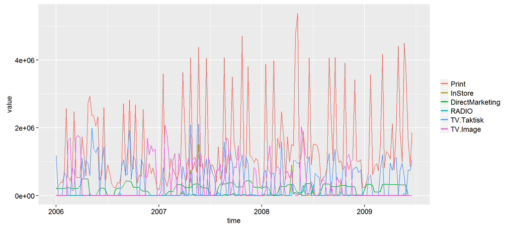

Figure 3.5: Plot of the media spending for each media type

```r
df4 <-BuildingSupplyStore[,c(25,17,18,19,20,21,22)]

df4 <- melt(df4,id=1)
ggplot(data = df4, aes(x=Rtime))+
geom_line(data = df4[df4$variable!="Media.adstock",], aes(y=value,colour=variable),size=0.4)+
geom_line(data=df4[df4$variable=="Media.adstock",], aes(y=value,colour=variable),size=0.8)+
theme(legend.title = element_blank())+
#theme(legend.title = element_text(colour=rgb(0,0,0), size=9 ))+
theme(legend.position="right")+
theme(legend.text = element_text(colour=rgb(0,0,0), size=9))+
theme(legend.background = element_rect(fill=rgb(1,1,1), size=0.2, linetype=2))+
theme(legend.key.size = unit(0.4, "cm"))+
theme(axis.text.x = element_text(size=9, colour = rgb(0,0,0)))+
theme(axis.text.y = element_text(size=9, colour = rgb(0,0,0)))+
theme(axis.title.x = element_text(size=9))+
theme(axis.title.y = element_text(size=9))+
labs(x = "time")
```

```r
adstock <- function(X,a){
  Y<-rep(NA, length(X))
  Y[1]<-X[1]
  for (i in 2:length(X)){
    Y[i]<-X[i]+a*Y[i-1]
  }
  return(Y)
}
attach(BuildingSupplyStore)

adstockLR <- function(x){

Media.adstock <-  adstock(Print,x[1])+ adstock(InStore,x[2])+ adstock(DirectMarketing,x[3])+adstock(RADIO,x[4])+adstock(TV.Taktisk,x[5])+adstock(TV.Image,x[6])
BuildingSupplyStore$Media.adstock <- Media.adstock
mod.fullLM <- lm(formula = Sales ~ Rtime + Season + Week.of.Month + Competitor.spending + Salgdage + Unemployment.rate + Tracking.smoothed + Respons.Media +Sol.Oslo+ Oslo...Mean.temperature + Oslo...Total.precipitation + Bergen...Mean.temperature + Bergen...Total.precipitation+ Media.adstock,data = BuildingSupplyStore)

return(coef(summary(mod.fullLM))["Media.adstock", 1] /coef(summary(mod.fullLM))["Media.adstock", 2] )

}

res <- optim(c(0.5,0.5,0.5,0.5,0.5,0.5), adstockLR,lower = 0.1,upper = 1,method = "L-BFGS-B",control=list(fnscale=-1))


BuildingSupplyStore$Print.adstock <- adstock(Print,res$par[1])
BuildingSupplyStore$InStore.adstock <- adstock(InStore,res$par[2])
BuildingSupplyStore$DirectMarketing.adstock <- adstock(DirectMarketing,res$par[3])
BuildingSupplyStore$RADIO.adstock <- adstock(RADIO,res$par[4])
BuildingSupplyStore$TV.Taktisk.adstock <- adstock(TV.Taktisk,res$par[5])
BuildingSupplyStore$TV.Image.adstock <- adstock(TV.Image,res$par[6])


BuildingSupplyStore$Media.adstock <- BuildingSupplyStore$Print.adstock + BuildingSupplyStore$InStore.adstock + BuildingSupplyStore$DirectMarketing.adstock + BuildingSupplyStore$RADIO.adstock + BuildingSupplyStore$TV.Image.adstock + BuildingSupplyStore$TV.Taktisk.adstock


pltList <- list()
for(i in 1:6){

df4 <-BuildingSupplyStore[,c(25,16+i,25+i)]
df4 <- melt(df4,id=1)
pltList[[ paste0("p", i) ]] <-  (ggplot(data = df4, aes(x=Rtime))+
geom_line(data = df4, aes(y=value,colour=variable),size=0.4)+
theme(legend.title = element_blank())+
#theme(legend.title = element_text(colour=rgb(0,0,0), size=9 ))+
theme(legend.position="top")+
theme(legend.text = element_text(colour=rgb(0,0,0), size=9))+
theme(legend.background = element_rect(fill=rgb(1,1,1), size=0.2, linetype=2))+
theme(legend.key.size = unit(0.4, "cm"))+
theme(axis.text.x = element_text(size=9, colour = rgb(0,0,0)))+
theme(axis.text.y = element_text(size=9, colour = rgb(0,0,0)))+
theme(axis.title.y = element_text(size=9))+
theme(axis.title.x = element_blank()))

}

multiplot(pltList[[1]],pltList[[2]],cols = 2)
multiplot(pltList[[3]],pltList[[4]],cols = 2)
multiplot(pltList[[5]],pltList[[6]],cols = 2)
```

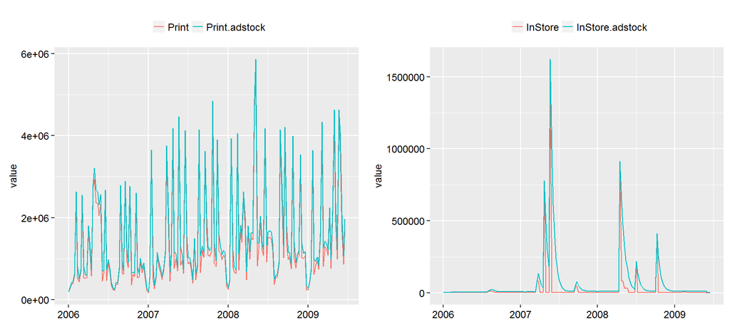

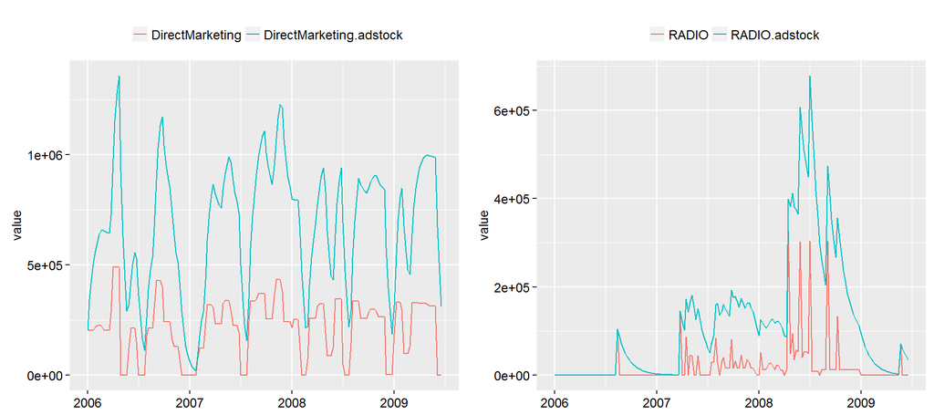

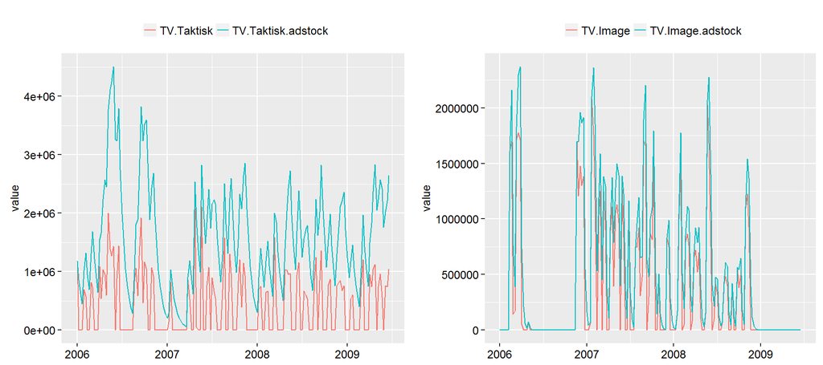

Figure 3.6: The optimized adstock variable for allt the media outlets

After the optimization we plotted the new variable Media.adstock along with the money spent on each of the media outlets. In fig.3.7 we can se the new variable, It seems to bee quite choppy and has a quite a bit of fluctuation in it but the haowever seems to do the trick to be able to reduce the error of the model.

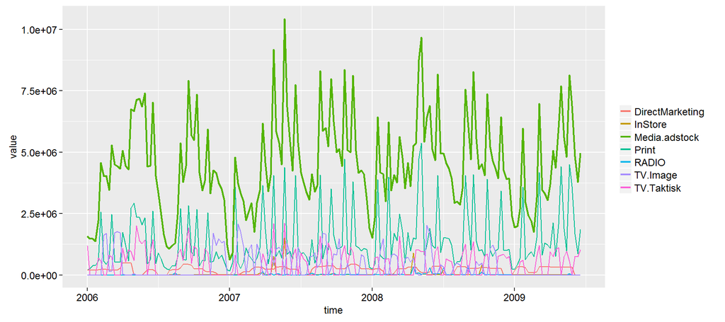

Figure 3.7: The Media.adstock variable along with the money invested in media advertisement

```r
df4 <-BuildingSupplyStore[,c(25,17,18,19,20,21,22,32)]

df4 <- melt(df4,id=1)
ggplot(data = df4, aes(x=Rtime))+
geom_line(data = df4[df4$variable!="Media.adstock",], aes(y=value,colour=variable),size=0.4)+
geom_line(data=df4[df4$variable=="Media.adstock",], aes(y=value,colour=variable),size=0.8)+
theme(legend.title = element_blank())+
#theme(legend.title = element_text(colour=rgb(0,0,0), size=9 ))+
theme(legend.position="right")+
theme(legend.text = element_text(colour=rgb(0,0,0), size=9))+
theme(legend.background = element_rect(fill=rgb(1,1,1), size=0.2, linetype=2))+
theme(legend.key.size = unit(0.4, "cm"))+
theme(axis.text.x = element_text(size=9, colour = rgb(0,0,0)))+
theme(axis.text.y = element_text(size=9, colour = rgb(0,0,0)))+
theme(axis.title.x = element_text(size=9))+
theme(axis.title.y = element_text(size=9))+
labs(x = "time")
```

So finaly can print out the summary for the model so far and print the residual and the ACF og the residuals. as we can se in fig.3.8 the residuals are looking a bit like white noize, some shift seems to be going on tin the later part of 2009. as we can se in the figure the autocorrelation is marginaly beond the confidence interval so we are getting closer to the final model.

```
##
## Call:
## lm(formula = Sales ~ Rtime + Season + Week.of.Month + Competitor.spending +
##     Salgdage + Unemployment.rate + Tracking.smoothed + Oslo...Mean.temperature +
##     Oslo...Total.precipitation + Bergen...Mean.temperature +
##     Bergen...Total.precipitation + Media.adstock, data = BuildingSupplyStore)
##
## Residuals:
##      Min       1Q   Median       3Q      Max
## -6215835 -1291621    77617  1223107  6234514
##
## Coefficients:
##                                Estimate Std. Error t value Pr(>|t|)
## (Intercept)                   1.596e+09  8.298e+08   1.923   0.0562 .
## Rtime                        -7.895e+05  4.113e+05  -1.919   0.0566 .
## Season                        5.238e-01  9.021e-02   5.806 3.12e-08 ***
## Week.of.Month                -7.419e+05  1.219e+05  -6.085 7.62e-09 ***
## Competitor.spending          -5.942e+05  4.180e+05  -1.421   0.1571
## Salgdage                      1.150e+05  2.174e+04   5.291 3.76e-07 ***
## Unemployment.rate            -2.039e+06  4.955e+05  -4.116 6.04e-05 ***
## Tracking.smoothed            -8.696e+03  9.865e+04  -0.088   0.9299
## Oslo...Mean.temperature       1.351e+05  7.565e+04   1.786   0.0760 .
## Oslo...Total.precipitation   -2.244e+03  8.970e+03  -0.250   0.8028
## Bergen...Mean.temperature    -2.932e+04  1.071e+05  -0.274   0.7846
## Bergen...Total.precipitation -5.403e+03  3.728e+03  -1.449   0.1492
## Media.adstock                 6.450e-01  1.020e-01   6.325 2.21e-09 ***
## ---
## Signif. codes:  0 '***' 0.001 '**' 0.01 '*' 0.05 '.' 0.1 ' ' 1
##
## Residual standard error: 2011000 on 168 degrees of freedom
## Multiple R-squared:  0.7238, Adjusted R-squared:  0.704
## F-statistic: 36.68 on 12 and 168 DF,  p-value: < 2.2e-16
```

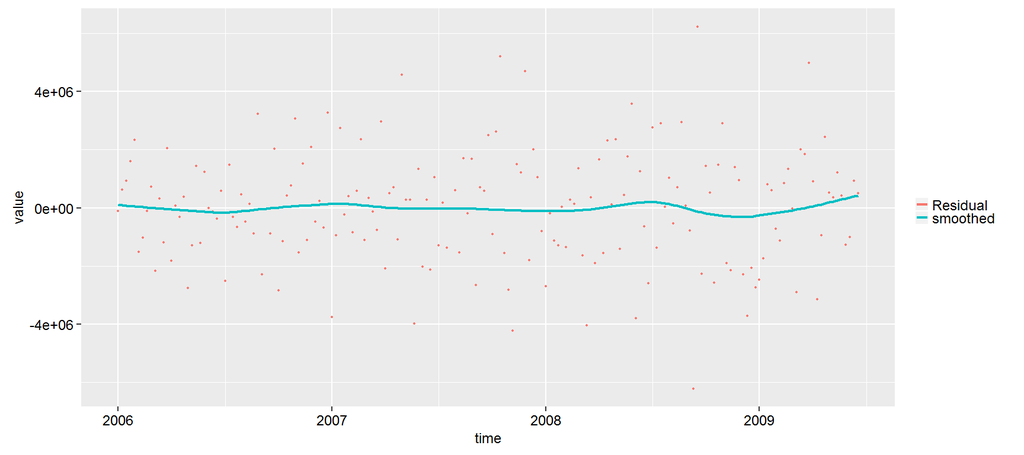

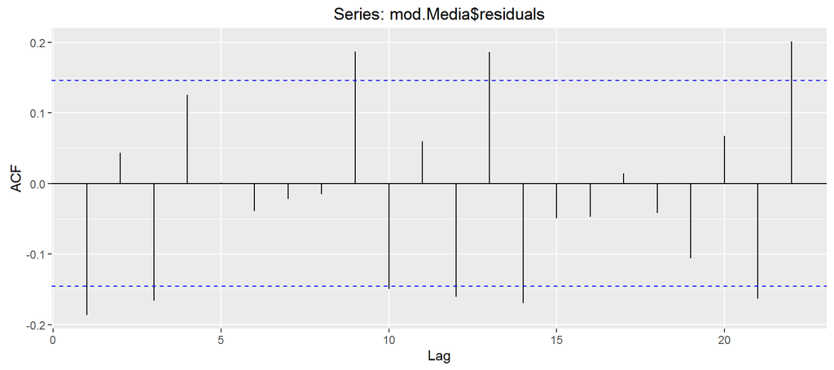

Figure 3.8: The residual plot and tha ACF af the residual

## 3.4 Task 4

To make tha best model fit we decided to make one Weater varable with a weighted average of all the wather data, this is done in a similar manner as tha optimization in task 3. we ar going to drop the competitiorspendinras itdoes notseem to improve the model as vell as add two newbinari variable to indicate if it is summer or christmas season.

```
##
## Call:
## lm(formula = Sales ~ Rtime + Season + Week.of.Month + Competitor.spending +
##     Salgdage + Unemployment.rate + Media.adstock + Weather, data = BuildingSupplyStore)
##
## Residuals:
##      Min       1Q   Median       3Q      Max
## -5551008 -1311922    69523  1184825  6652816
##
## Coefficients:
##                       Estimate Std. Error t value Pr(>|t|)
## (Intercept)          1.553e+09  4.634e+08   3.351 0.000988 ***
## Rtime               -7.693e+05  2.314e+05  -3.324 0.001083 **
## Season               5.170e-01  8.616e-02   6.000 1.13e-08 ***
## Week.of.Month       -7.393e+05  1.203e+05  -6.147 5.34e-09 ***
## Competitor.spending -5.417e+05  4.069e+05  -1.331 0.184904
## Salgdage             1.157e+05  2.134e+04   5.423 1.96e-07 ***
## Unemployment.rate   -1.975e+06  3.800e+05  -5.198 5.67e-07 ***
## Media.adstock        6.503e-01  1.000e-01   6.500 8.37e-10 ***
## Weather              2.353e+04  5.006e+03   4.699 5.33e-06 ***
## ---
## Signif. codes:  0 '***' 0.001 '**' 0.01 '*' 0.05 '.' 0.1 ' ' 1
##
## Residual standard error: 2e+06 on 172 degrees of freedom
## Multiple R-squared:  0.7204, Adjusted R-squared:  0.7074
## F-statistic:  55.4 on 8 and 172 DF,  p-value: < 2.2e-16
```

```
##
## Call:
## lm(formula = Sales ~ Rtime + Season + Week.of.Month + Competitor.spending +
##     Salgdage + Unemployment.rate + Media.adstock + Weather +
##     isChristmas + isSummer, data = BuildingSupplyStore)
##
## Residuals:
##      Min       1Q   Median       3Q      Max
## -5605593 -1197350    27342  1044443  6529571
##
## Coefficients:
##                       Estimate Std. Error t value Pr(>|t|)
## (Intercept)          1.448e+09  4.704e+08   3.079 0.002422 **
## Rtime               -7.160e+05  2.350e+05  -3.047 0.002684 **
## Season               5.272e-01  8.740e-02   6.032 9.80e-09 ***
## Week.of.Month       -7.185e+05  1.216e+05  -5.907 1.85e-08 ***
## Competitor.spending -6.941e+05  4.232e+05  -1.640 0.102815
## Salgdage             1.129e+05  2.145e+04   5.263 4.23e-07 ***
## Unemployment.rate   -1.990e+06  3.824e+05  -5.205 5.53e-07 ***
## Media.adstock        6.568e-01  1.080e-01   6.079 7.72e-09 ***
## Weather              2.198e+04  5.799e+03   3.790 0.000209 ***
## isChristmas         -8.985e+05  6.766e+05  -1.328 0.185953
## isSummer             5.888e+04  5.284e+05   0.111 0.911393
## ---
## Signif. codes:  0 '***' 0.001 '**' 0.01 '*' 0.05 '.' 0.1 ' ' 1
##
## Residual standard error: 2001000 on 170 degrees of freedom
## Multiple R-squared:  0.7233, Adjusted R-squared:  0.707
## F-statistic: 44.44 on 10 and 170 DF,  p-value: < 2.2e-16
```

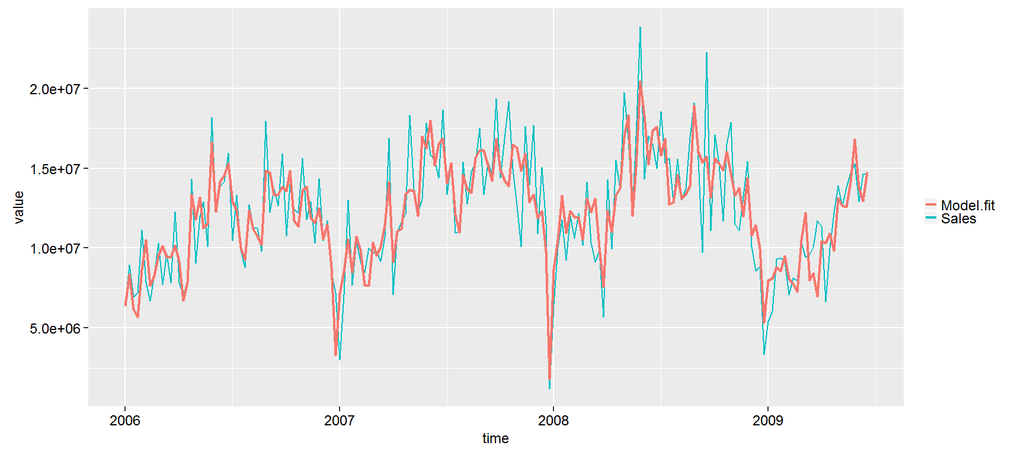

Figure 3.9: Here we have a slightly better fit with the logical variables for season

```
##
## Call:
## lm(formula = Sales ~ Rtime + Season + Week.of.Month + Salgdage +
##     Unemployment.rate + Media.adstock + Weather + isChristmas +
##     isSummer + Mseason, data = BuildingSupplyStore)
##
## Residuals:
##      Min       1Q   Median       3Q      Max
## -2855638  -939442  -157281   772030  3981842
##
## Coefficients:
##                     Estimate Std. Error t value Pr(>|t|)
## (Intercept)        4.030e+08  3.231e+08   1.247  0.21400
## Rtime             -2.025e+05  1.611e+05  -1.257  0.21048
## Season             4.608e-01  5.893e-02   7.819 5.33e-13 ***
## Week.of.Month     -4.668e+05  8.355e+04  -5.587 9.02e-08 ***
## Salgdage           2.393e+04  1.534e+04   1.560  0.12064
## Unemployment.rate -5.851e+05  2.726e+05  -2.146  0.03326 *
## Media.adstock      2.046e-01  7.090e-02   2.885  0.00442 **
## Weather            2.752e+04  3.850e+03   7.147 2.49e-11 ***
## isChristmas       -2.224e+05  4.383e+05  -0.507  0.61251
## isSummer           7.448e+05  3.580e+05   2.081  0.03897 *
## Mseason            7.521e-01  5.163e-02  14.567  < 2e-16 ***
## ---
## Signif. codes:  0 '***' 0.001 '**' 0.01 '*' 0.05 '.' 0.1 ' ' 1
##
## Residual standard error: 1345000 on 170 degrees of freedom
## Multiple R-squared:  0.875,  Adjusted R-squared:  0.8676
## F-statistic:   119 on 10 and 170 DF,  p-value: < 2.2e-16
```

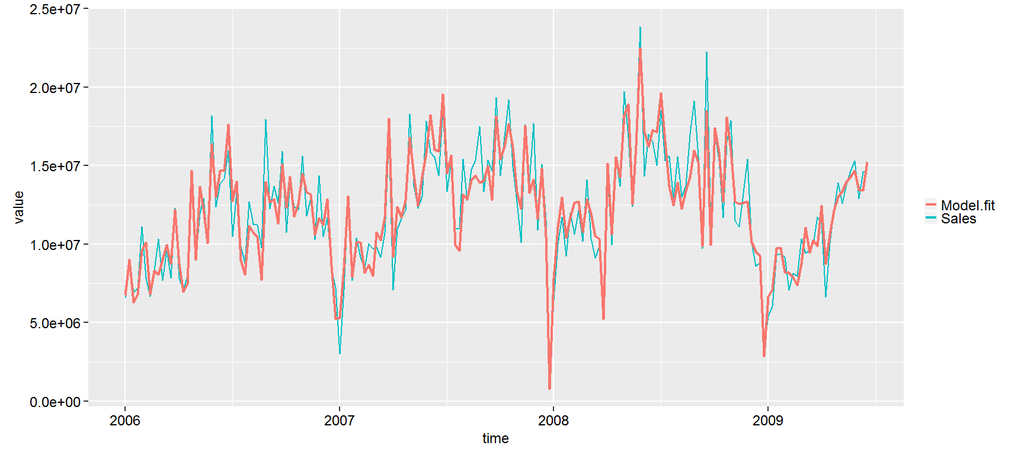

Figure 3.10: The final model. we can se it fits tha data a lot better then the first model